# Task 2 - Parameter Estimation - Lizards Length to Weight

Samantha Kuglen

2/7/2022

```r
knitr::opts_chunk$set(echo = TRUE, warning = FALSE, message = FALSE)

#Attach packages
library(tidyverse)
library(here)
library(janitor)
library(broom)
library(caret)
library(kableExtra)
library(modelr)
```

### A. Overview

The purpose of this code is to utilize non-linear least squares to estimate parameters of a length to weight model for lizard populations in New Mexico at the Jornada Basin LTER site.

**Data Citation**: Source: Lightfoot, D. and W.G. Whitford. 2020. Lizard pitfall trap data from 11 NPP study locations at the Jornada Basin LTER site, 1989-2006 ver 37. Environmental Data Initiative. https://doi.org/10.6073/pasta/4a6e258fb49c31e222ecbbcfd128967f

### B. Data and Analysis

Read in the data and update sex in the table to be full name (i.e. Male and Female).

```r
lizards <- read_csv(here("data", "lizard.csv")) %>%
    mutate(sex = case_when(sex == 'F' ~ 'Female',
                         sex == 'M' ~ 'Male')) %>%
  clean_names()
```

#### I. Snout Length to Weight Model

A snout length to weight model of the following form is used for all lizards in the dataframe. The equation is:

$$W = a(SVL)^b\$$
Where `weight` is given by W, snout to vent length by `SVL`, and `a` and `b` are the parameters that need to be fitted. Since the model is exponential in nature, we will log transform the data. Then, use standard OLS regression on the log transformed data to get approximations of the parameters `a` and `b` from the regression coefficients.

```r
# model function
weight_function <- function(a, sv_length, b) {
  weight = a * (sv_length)^b
  return(weight)
}

# log transform the data
lizards_log <- lizards %>%
  mutate(log_weight = log(weight)) %>%
  mutate(log_length = log(sv_length))

# standard OLS regression on log transformed data
guess_model <- lm(log_weight ~ log_length, data = lizards_log)
tidy_guess_model <- tidy(guess_model)

# Using coefficients function, supply nls start list with regression coefficients
coef <- coefficients(guess_model)

# Mathematically transform intercept coefficient to get guess for parameter a
lizards_nls <- nls(weight ~ weight_function(a, sv_length, b),
                  data = lizards,
                  start = list(
                    a = 2.718^(coef[1]/coef[2]),
                    b = coef[2]),
                    trace = TRUE)
```

```
## 2.309002e+09 (3.87e+02): par = (0.0354286 2.537119)
## 37258.06    (1.19e+00): par = (0.0003458809 2.536411)
## 15903.54    (1.68e-01): par = (0.0003460121 2.464334)
## 15467.24    (5.36e-03): par = (0.0003446172 2.451287)
## 15466.81    (5.15e-04): par = (0.0003404191 2.45366)
## 15466.80    (1.18e-04): par = (0.0003412931 2.453084)
## 15466.80    (2.88e-05): par = (0.0003410855 2.453225)
## 15466.80    (7.04e-06): par = (0.0003411367 2.453191)
```

```r
# Update p-values since they are very small to be < 0.001
tidy_nls_table <- tidy(lizards_nls) %>%
  select(-statistic) %>%
  mutate(p.value = ifelse(p.value < 0.001, "< 0.001"))

# Table formatting
kable(tidy_nls_table,
      col = c("Parameter", "Estimate", "Std Error", "p-value"), digits = 5,
      caption = "Table 1. Approximation of Parameters from Regression Coefficients") %>%
  kable_styling(bootstrap_options = "striped",
                full_width = FALSE)
```

Table 1. Approximation of Parameters from Regression Coefficients

| Parameter | Estimate | Std Error | p-value |
| --- | --- | --- | --- |
| a | 0.00034 | 0.00004 | < 0.001 |
| b | 2.45319 | 0.02698 | < 0.001 |

```r
model_fitted <- lizards_nls %>%
  broom::augment(type.predict = "response")
```

Regression coefficients: Intercept of the initial guess model is -8.48. The log length is 2.54.

#### II. Fitted Model Plot of Female and Male Lizards

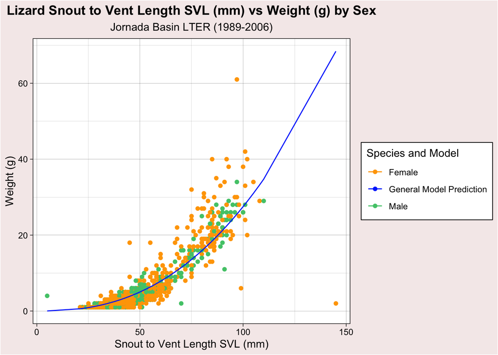

```r
ggplot(lizards, aes(x = sv_length, y = weight, color = sex)) +
  geom_point(aes(x = sv_length, y = weight, color = sex)) +
  geom_line(data = model_fitted, aes(x = sv_length, y = .fitted, color = "General Model Prediction")) +
  theme_linedraw() +
  labs(x = "Snout to Vent Length SVL (mm)",
       y = "Weight (g)",
       title = "Lizard Snout to Vent Length SVL (mm) vs Weight (g) by Sex",
       subtitle = "Jornada Basin LTER (1989-2006)",
       color = "Species and Model") +
  scale_color_manual(values = c( "orange", "#0339fc", "#50C878")) +
  theme(plot.title = element_text(hjust = 0.5, face = "bold"), # center title/subtitle
        plot.subtitle = element_text(hjust = 0.5),
        plot.background = element_rect(fill = "#f5ebeb"), # change background color
        legend.background = element_blank(),
        legend.box.background = element_rect(colour = "black")) # frame around legend
```

**Figure 1.** Fitted non-linear regression model prediction plotted over data points of snout to vent length (mm) vs weight (g) for all lizards in the dataset, with female and male lizards separated by color. Data: Lightfoot, D. and W.G. Whitford. 2020.

#### III. Data Visualization of NLS Model for Subset of Male Western Whiptail lizard *(Cnemidophorus tigrisatus)*

We will create a species-specific subset model for male western whiptails only.

```r
whiptail <- lizards %>%
  filter(spp == "CNTI" & sex == "Male")

# log transform the data again
whip_log <- whiptail %>%
  mutate(log_weight = log(weight)) %>%
  mutate(log_length = log(sv_length))

# standard OLS regression on log transformed data
whip_model <- lm(log_weight ~ log_length, data = whip_log)
tidy_whip_model <- tidy(whip_model)

# Using coefficients function, supply nls start list with regression coefficients
whip_coef <- coefficients(whip_model)

# Mathematically transform intercept coefficient to get guess for parameter a

whip_nls <- nls(weight ~ weight_function(a, sv_length, b),
                  data = whiptail,
                  start = list(
                    a = 2.718^(coef[1]/coef[2]),
                    b = whip_coef[2]),
                    trace = TRUE)
```

```
## 2.337431e+09 (1.71e+03): par = (0.0354286 2.698108)
## 74451.02    (9.57e+00): par = (0.0003210173 2.696851)
## 5602.768    (2.44e+00): par = (0.0003220544 2.557812)
## 808.3604    (3.04e-02): par = (0.0004410967 2.409761)
## 808.1249    (2.44e-02): par = (0.0004636693 2.398385)
## 808.1066    (2.33e-02): par = (0.0004984119 2.38187)
## 807.8293    (1.38e-02): par = (0.0005335038 2.366962)
## 807.6756    (9.96e-05): par = (0.0005312628 2.368427)
## 807.6756    (8.80e-06): par = (0.0005315999 2.368287)
```

```r
whip_model_fitted <- whip_nls %>%
  broom::augment(type.predict = "response")
```

Comparison of the output from the species-specific nls model to the general nls model for all species by graphing the model fits on the Western Whiptail male data.

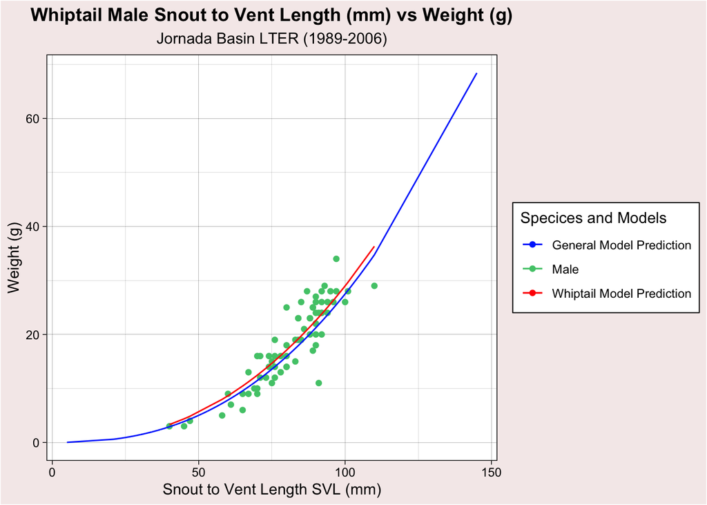

```r
# Calculate RMSE values

# Model fits on Western Whiptail male points
ggplot(whiptail, aes(x = sv_length, y = weight, color = sex)) +
  geom_point(aes(x = sv_length, y = weight, color = sex)) +
  geom_line(data = model_fitted, aes(x = sv_length,
                                     y = .fitted,
                                     color = "General Model Prediction")) + # general nls
  geom_line(data = whip_model_fitted, aes(x = sv_length,
                                          y = .fitted,
                                          color = "Whiptail Model Prediction")) + # whip nls
  theme_linedraw() +
  labs(x = "Snout to Vent Length SVL (mm)",
       y = "Weight (g)",
       title = "Whiptail Male Snout to Vent Length (mm) vs Weight (g)",
       subtitle = "Jornada Basin LTER (1989-2006)",
       color = "Specices and Models") +
  scale_color_manual(values = c("#0339fc", "#50C878", "red")) +
  theme(plot.title = element_text(hjust = 0.5, face = "bold"), # center title/subtitle
        plot.subtitle = element_text(hjust = 0.5),
        plot.background = element_rect(fill = "#f5ebeb"), # change background color
        legend.background = element_blank(),
        legend.box.background = element_rect(colour = "black")) # frame around legend
```

```r
lizards_rmse <- rmse(lizards_nls, data = whip_log)
whip_rmse <- rmse(whip_nls, data = whip_log)
```